# Predicting Salaries of Different Data Science Jobs

## Phase 1: Data Preparation and Visualisation

### Group Number: Group 28

### Group Members:

- Lance Belen (s3944846)
- Darby Vogt (s3948074)
- Laura Gatt (s3945256)
- Luke Zuell (s3948720)
- Introduction
  - Dataset Source
  - Dataset Details
  - Dataset Variables
  - Response Variable
- Goals & Objectives
- Data Cleaning & Preprocessing
  - Check Current Features
  - Check for Missing Values & The Data Types
  - Outliers & Unusual Values
- Data Exploration & Visualisation
  - One-Variable Plots
  - Two-Variable Plots
  - Three-Variable Plots
- Summary & Conclusion
- References

## Introduction

### Dataset Source

The source of the dataset in this study is Kaggle (Ruchi Bhatia, June 2022). This dataset includes salaries of different data science jobs from 2020 to 2022 as well as other features such as experience level, employment type, and company size.

### Dataset Details

The dataset contains the salaries of data scientists in different data science jobs. It also includes the level of experience that they have, theirs and their company's location, and their remote ratio (i.e. if they work fully remote, partially, etc.). Other features that is included are the size of the company that they work in, another currency (aside form USD), and their salary in that currency.

There are 607 observations and 11 features in this dataset.

```python
import warnings
warnings.filterwarnings("ignore")

import numpy as np
import pandas as pd

pd.set_option('display.max_columns', None)

###
import matplotlib.pyplot as plt
import seaborn as sns
%matplotlib inline
%config InlineBackend.figure_format = 'retina'
plt.style.use("seaborn")
###
```

```python
# Read the dataset and display 10 random observations
url = 'https://raw.githubusercontent.com/LukeZuellRMIT/mathsDataset/main/mathsfile.csv?token=GHSAT0AAAAAABYNYANXDNUWKVMMACFPQZSUYZWEISA'
ds_data = pd.read_csv(url, index_col = False)
ds_data.sample(10, random_state = 1)
```

|  | work_year | experience_level | employment_type | job_title | salary | salary_currency | salary_in_usd | employee_residence | remote_ratio | company_location | company_size |
| --- | --- | --- | --- | --- | --- | --- | --- | --- | --- | --- | --- |
| 65 | 2020 | EN | FT | Data Scientist | 55000 | EUR | 62726 | DE | 50 | DE | S |
| 237 | 2021 | MI | FT | Data Scientist | 39600 | EUR | 46809 | ES | 100 | ES | M |
| 147 | 2021 | MI | FT | Data Engineer | 90000 | USD | 90000 | US | 100 | US | L |
| 464 | 2022 | SE | FT | Principal Data Scientist | 148000 | EUR | 162674 | DE | 100 | DE | M |
| 187 | 2021 | EX | FT | Data Science Consultant | 59000 | EUR | 69741 | FR | 100 | ES | S |
| 233 | 2021 | SE | FT | Data Analyst | 200000 | USD | 200000 | US | 100 | US | L |
| 339 | 2022 | SE | FT | Data Analyst | 109280 | USD | 109280 | US | 100 | US | M |
| 482 | 2022 | EX | FT | Data Engineer | 324000 | USD | 324000 | US | 100 | US | M |
| 241 | 2021 | MI | FT | Data Analyst | 80000 | USD | 80000 | US | 100 | US | L |
| 88 | 2021 | SE | FT | Lead Data Analyst | 170000 | USD | 170000 | US | 100 | US | L |

### Dataset Variables

The description for the variables in the dataset are below. This is obtained from the Kaggle data source which is referenced at the end of this report.

```python
from tabulate import tabulate

table = [['Name', 'Data Type', 'Unit', 'Description'],
        ['work_year', 'Date', 'Year', 'The year the salary was paid.'],
        ['experience_level', 'Ordinal Categorical', 'N/A',
         'The experience level in the job during the year with the following\npossible values: EN Entry-level / Junior MI Mid-level /\nIntermediate SE Senior-level / Expert EX Executive-level / Director'],
        ['employment_type', 'Nominal Categorical', 'N/A', 'The type of employement for the role:\nPT Part-time FT Full-time CT Contract FL Freelance'],
        ['job_title', 'Nominal Categorical', 'N/A', 'The role worked in during the year.'],
        ['salary_in_usd', 'Numerical', 'USD', 'The salary in USD (FX rate divided by avg.\nUSD rate for the respective year via fxdata.foorilla.com).'],
        ['employee_residence', 'Nominal Categorical', 'N/A', 'Employee\'s primary country of residence in\nduring the work year as an ISO 3166 country code.'],
        ['remote_ratio', 'Nominal Categorical', 'N/A', 'The overall amount of work done remotely, possible values are as follows:\n0 No remote work (less than 20%) 50 Partially remote\n100 Fully remote (more than 80%)'],
        ['company_location', 'Nominal Categorical', 'N/A', 'The country of the employer\'s main office or contracting branch\nas an ISO 3166 country code.'],
        ['company_size', 'Ordinal Categorical', 'S/M/L', 'The average number of people that worked for the company during the year:\nS less than 50 employees (small) M 50 to 250 employees (medium)\nL more than 250 employees (large)' ]]

print(tabulate(table, headers='firstrow', tablefmt = 'fancy_grid'))
```

```
╒════════════════════╤═════════════════════╤════════╤═══════════════════════════════════════════════════════════════════════════╕
│ Name               │ Data Type           │ Unit   │ Description                                                               │
╞════════════════════╪═════════════════════╪════════╪═══════════════════════════════════════════════════════════════════════════╡
│ work_year          │ Date                │ Year   │ The year the salary was paid.                                             │
├────────────────────┼─────────────────────┼────────┼───────────────────────────────────────────────────────────────────────────┤
│ experience_level   │ Ordinal Categorical │ N/A    │ The experience level in the job during the year with the following        │
│                    │                     │        │ possible values: EN Entry-level / Junior MI Mid-level /                   │
│                    │                     │        │ Intermediate SE Senior-level / Expert EX Executive-level / Director       │
├────────────────────┼─────────────────────┼────────┼───────────────────────────────────────────────────────────────────────────┤
│ employment_type    │ Nominal Categorical │ N/A    │ The type of employement for the role:                                     │
│                    │                     │        │ PT Part-time FT Full-time CT Contract FL Freelance                        │
├────────────────────┼─────────────────────┼────────┼───────────────────────────────────────────────────────────────────────────┤
│ job_title          │ Nominal Categorical │ N/A    │ The role worked in during the year.                                       │
├────────────────────┼─────────────────────┼────────┼───────────────────────────────────────────────────────────────────────────┤
│ salary_in_usd      │ Numerical           │ USD    │ The salary in USD (FX rate divided by avg.                                │
│                    │                     │        │ USD rate for the respective year via fxdata.foorilla.com).                │
├────────────────────┼─────────────────────┼────────┼───────────────────────────────────────────────────────────────────────────┤
│ employee_residence │ Nominal Categorical │ N/A    │ Employee's primary country of residence in                                │
│                    │                     │        │ during the work year as an ISO 3166 country code.                         │
├────────────────────┼─────────────────────┼────────┼───────────────────────────────────────────────────────────────────────────┤
│ remote_ratio       │ Nominal Categorical │ N/A    │ The overall amount of work done remotely, possible values are as follows: │
│                    │                     │        │ 0 No remote work (less than 20%) 50 Partially remote                      │
│                    │                     │        │ 100 Fully remote (more than 80%)                                          │
├────────────────────┼─────────────────────┼────────┼───────────────────────────────────────────────────────────────────────────┤
│ company_location   │ Nominal Categorical │ N/A    │ The country of the employer's main office or contracting branch           │
│                    │                     │        │ as an ISO 3166 country code.                                              │
├────────────────────┼─────────────────────┼────────┼───────────────────────────────────────────────────────────────────────────┤
│ company_size       │ Ordinal Categorical │ S/M/L  │ The average number of people that worked for the company during the year: │
│                    │                     │        │ S less than 50 employees (small) M 50 to 250 employees (medium)           │
│                    │                     │        │ L more than 250 employees (large)                                         │
╘════════════════════╧═════════════════════╧════════╧═══════════════════════════════════════════════════════════════════════════╛
```

### Response Variable

For this study, the target feature will be the salary (i.e. salary_in_usd). Predictions will be made on this feature as a result of the explanatory/descriptive variables.

## Goals & Objectives

The Data Science Industry has a range of job salaries depending on different factors. It can be difficult to know which job will give a person the highest or most realistic salary, so being able to predict the try of salary depending on different factors such as company size and location will save many users the time and trouble of searching for the right job. A situation where this would be useful is if someone has been offered a position in a small company and would like to check the salary predictor to see what the average salary in a data science position might be in a smaller company. Likewise, if that person was also planning on being a full time employee, they can check if there is much difference (on average) between salaries for full time employees vs part time employees etc.

The focus and objective of this project will be: to predict the salaries of different job titles in the Data Science workforce determined on specific features such as job title, employment type or employee residence. Another goal/ objective is to ultimately find which of the many features are the most effective and accurate at predicting the salary. To achieve this, we aim to create a variety of data visualization plots to help visually represent and show the relevant data and to make informed decisions about which features are most effective at predicting the salary. Some data cleaning and preprocessing will also take place prior to, ensuring the data has been sifted through.

## Data Cleaning & Preprocessing

In this section, the dataset will be prepared for modelling. The whole process will be described below.

#### Check Current Features

To start this off, we will first check the columns that are currently in the dataset, and drop the ones that are not necessary for modelling.

```python
list(ds_data.columns)
```

```
['work_year',
 'experience_level',
 'employment_type',
 'job_title',
 'salary',
 'salary_currency',
 'salary_in_usd',
 'employee_residence',
 'remote_ratio',
 'company_location',
 'company_size']
```

There are two features that are correlated to each other, one of which is correlated to another separate feature. The columns 'salary' and 'salary_in_usd' refer to the same numerical amount, but in different units (currency). Moreover, 'salary' is also connected to 'salary_currency', which describes the currency for the 'salary' feature.

For this reason, we will only keep the feature 'salary_in_usd' to maintain consistency as we only need one of the three correlated features. Hence, we will drop 'salary' and 'salary_currency'.

```python
ds_data = ds_data.drop(columns = ['salary', 'salary_currency'])
```

```python
ds_data
```

|  | work_year | experience_level | employment_type | job_title | salary_in_usd | employee_residence | remote_ratio | company_location | company_size |
| --- | --- | --- | --- | --- | --- | --- | --- | --- | --- |
| 0 | 2020 | MI | FT | Data Scientist | 79833 | DE | 0 | DE | L |
| 1 | 2020 | SE | FT | Machine Learning Scientist | 260000 | JP | 0 | JP | S |
| 2 | 2020 | SE | FT | Big Data Engineer | 109024 | GB | 50 | GB | M |
| 3 | 2020 | MI | FT | Product Data Analyst | 20000 | HN | 0 | HN | S |
| 4 | 2020 | SE | FT | Machine Learning Engineer | 150000 | US | 50 | US | L |
| ... | ... | ... | ... | ... | ... | ... | ... | ... | ... |
| 602 | 2022 | SE | FT | Data Engineer | 154000 | US | 100 | US | M |
| 603 | 2022 | SE | FT | Data Engineer | 126000 | US | 100 | US | M |
| 604 | 2022 | SE | FT | Data Analyst | 129000 | US | 0 | US | M |
| 605 | 2022 | SE | FT | Data Analyst | 150000 | US | 100 | US | M |
| 606 | 2022 | MI | FT | AI Scientist | 200000 | IN | 100 | US | L |

607 rows × 9 columns

#### Check for Missing Values & The Data Types

Next, we will deal with observations that has missing values.

Let's first check if there are any in the dataset.

```python
ds_data.isna().sum()
```

```
work_year             0
experience_level      0
employment_type       0
job_title             0
salary_in_usd         0
employee_residence    0
remote_ratio          0
company_location      0
company_size          0
dtype: int64
```

As seen from above, the dataset has no missing values.

Let us now ensure that we have the appropriate data types.

```python
print('DATA TYPES:\n')
print('object is a string type.')
ds_data.dtypes
```

```
DATA TYPES:

object is a string type.
```

```
work_year              int64
experience_level      object
employment_type       object
job_title             object
salary_in_usd          int64
employee_residence    object
remote_ratio           int64
company_location      object
company_size          object
dtype: object
```

The data types are as intended, hence, there are no necessary changes to be made.

#### Outliers & Unusual Values

Next, we will check if there are any outliers or unusual values in the dataset (such as irregular cardinalities, negative values for salary or year, etc).

```python
columns = list(ds_data.columns)

for feature in columns:
    print(f'The unique values in \'{feature}\' are:')
    print(f'{ds_data[feature].unique()}\n')
```

```
The unique values in 'work_year' are:
[2020 2021 2022]

The unique values in 'experience_level' are:
['MI' 'SE' 'EN' 'EX']

The unique values in 'employment_type' are:
['FT' 'CT' 'PT' 'FL']

The unique values in 'job_title' are:
['Data Scientist' 'Machine Learning Scientist' 'Big Data Engineer'
 'Product Data Analyst' 'Machine Learning Engineer' 'Data Analyst'
 'Lead Data Scientist' 'Business Data Analyst' 'Lead Data Engineer'
 'Lead Data Analyst' 'Data Engineer' 'Data Science Consultant'
 'BI Data Analyst' 'Director of Data Science' 'Research Scientist'
 'Machine Learning Manager' 'Data Engineering Manager'
 'Machine Learning Infrastructure Engineer' 'ML Engineer' 'AI Scientist'
 'Computer Vision Engineer' 'Principal Data Scientist'
 'Data Science Manager' 'Head of Data' '3D Computer Vision Researcher'
 'Data Analytics Engineer' 'Applied Data Scientist'
 'Marketing Data Analyst' 'Cloud Data Engineer' 'Financial Data Analyst'
 'Computer Vision Software Engineer' 'Director of Data Engineering'
 'Data Science Engineer' 'Principal Data Engineer'
 'Machine Learning Developer' 'Applied Machine Learning Scientist'
 'Data Analytics Manager' 'Head of Data Science' 'Data Specialist'
 'Data Architect' 'Finance Data Analyst' 'Principal Data Analyst'
 'Big Data Architect' 'Staff Data Scientist' 'Analytics Engineer'
 'ETL Developer' 'Head of Machine Learning' 'NLP Engineer'
 'Lead Machine Learning Engineer' 'Data Analytics Lead']

The unique values in 'salary_in_usd' are:
[ 79833 260000 109024  20000 150000  72000 190000  35735 135000 125000
  51321  40481  39916  87000  85000   8000  41689 114047   5707  56000
  43331   6072  47899  98000 115000 325000  42000  33511 100000 117104
  59303  70000  68428 450000  46759  74130 103000 250000  10000 138000
  45760  50180 106000 112872  15966  76958 188000 105000  70139  91000
  45896  54742  60000 148261  38776 118000 120000 138350 110000 130800
  21669 412000  45618  62726  49268 190200  91237  42197  82528 235000
  53192   5409 270000  80000  79197 140000  54238  47282 153667  28476
  59102 170000  88654  76833  19609 276000  29751  89294  12000  95746
```

[output cut: 32 more lines]

```
 'BR' 'IQ' 'VN' 'BE' 'UA' 'MT' 'CL' 'RO' 'IR' 'CO' 'MD' 'KE' 'SI' 'HK'
 'TR' 'RS' 'PR' 'LU' 'JE' 'CZ' 'AR' 'DZ' 'TN' 'MY' 'EE' 'AU' 'BO' 'IE'
 'CH']

The unique values in 'remote_ratio' are:
[  0  50 100]

The unique values in 'company_location' are:
['DE' 'JP' 'GB' 'HN' 'US' 'HU' 'NZ' 'FR' 'IN' 'PK' 'CN' 'GR' 'AE' 'NL'
 'MX' 'CA' 'AT' 'NG' 'ES' 'PT' 'DK' 'IT' 'HR' 'LU' 'PL' 'SG' 'RO' 'IQ'
 'BR' 'BE' 'UA' 'IL' 'RU' 'MT' 'CL' 'IR' 'CO' 'MD' 'KE' 'SI' 'CH' 'VN'
 'AS' 'TR' 'CZ' 'DZ' 'EE' 'MY' 'AU' 'IE']

The unique values in 'company_size' are:
['L' 'S' 'M']
```

The values and cardinalities for each column are as expected, therefore, there are no necessary changes to be made.

Finally, let us display 5 random rows from the cleaned dataset.

```python
ds_data.sample(5, random_state = 2)
```

|  | work_year | experience_level | employment_type | job_title | salary_in_usd | employee_residence | remote_ratio | company_location | company_size |
| --- | --- | --- | --- | --- | --- | --- | --- | --- | --- |
| 520 | 2022 | MI | FT | Data Scientist | 69336 | CA | 100 | CA | M |
| 335 | 2022 | SE | FT | Data Engineer | 132320 | US | 100 | US | M |
| 524 | 2022 | MI | FT | Data Scientist | 135000 | US | 100 | US | L |
| 459 | 2022 | MI | FT | Data Scientist | 31615 | IN | 100 | IN | L |
| 131 | 2021 | EN | FT | Data Scientist | 49646 | FR | 50 | FR | M |

## Data Exploration & Visualisation

### One-Variable Plots

#### Bar chart of Employment Type

The kick this all off, Figure 1 displays all the different Employment Types that Data Scientists are. The majority of these are Full Time employees, which fits in the with typical employee working a 9-5 full time job. This also diplays that for the all of the other data present, they are most likely a full time employee.

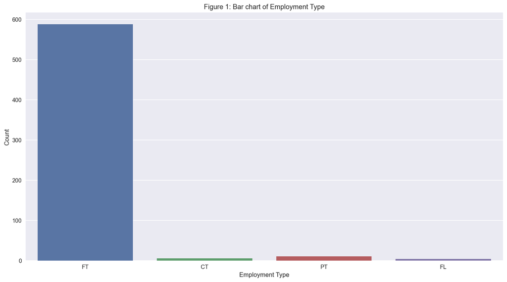

```python
plt.figure(figsize = (15,8))
ax = sns.countplot(x=ds_data['employment_type'])
plt.xlabel('Employment Type')
plt.ylabel('Count')
plt.title('Figure 1: Bar chart of Employment Type')
plt.show()
```

#### Bar chart of Remote Ratio

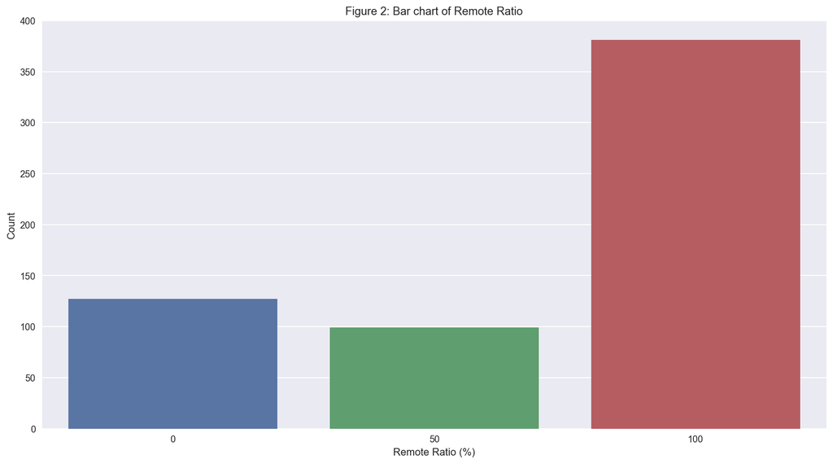

```python
plt.figure(figsize = (15,8))
ax = sns.countplot(x=ds_data['remote_ratio'])
plt.xlabel('Remote Ratio (%)')
plt.ylabel('Count')
plt.title('Figure 2: Bar chart of Remote Ratio')
plt.show()
```

#### Bar chart of Company Size

The results in Figure 3 display the spread of workforce sizes for Data Science Employees. This data consists of the most common worksize being Medium, followed by Large and Small respectively. This highlights the trend that the Data Scientists work in a Medium to Large sized workplace.

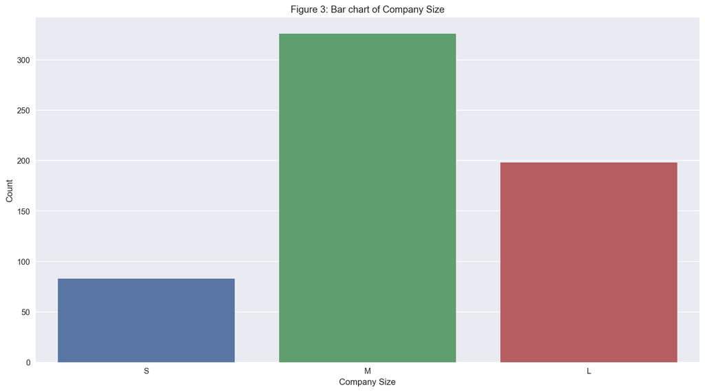

```python
plt.figure(figsize = (15,8))
ax = sns.countplot(x=ds_data['company_size'], order = ['S', 'M', 'L'])
plt.xlabel('Company Size')
plt.ylabel('Count')
plt.title('Figure 3: Bar chart of Company Size')
plt.show()
```

#### Histogram of Salary

The Figure 4 History displays the positively skewed distribution in the pay of Data Scientists, being that the majority are paid around $100k, with the number then lowering until 450k, with an outlier at 600k. This data would be better represented with a 2 or 3 variable plot as we have below.

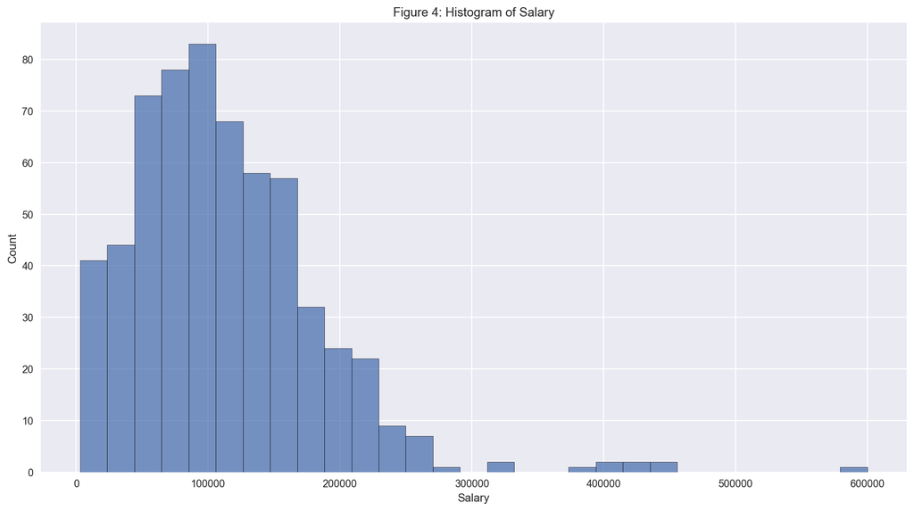

```python
plt.figure(figsize = (15,8))
sns.histplot(ds_data['salary_in_usd'])
plt.xlabel('Salary')
plt.title('Figure 4: Histogram of Salary')
plt.show()
```

#### Bar chart of Experience Level

For Figure 5, we observed that the experience level for Data Science Job Salaries. The most common experience level was Senior Level, followed by Mid Level. This trend displays the working in this Enviroment is a stable job, with the number of Senior and Mid Level employees severly outweighting the number of Junior and Executive Level employees.

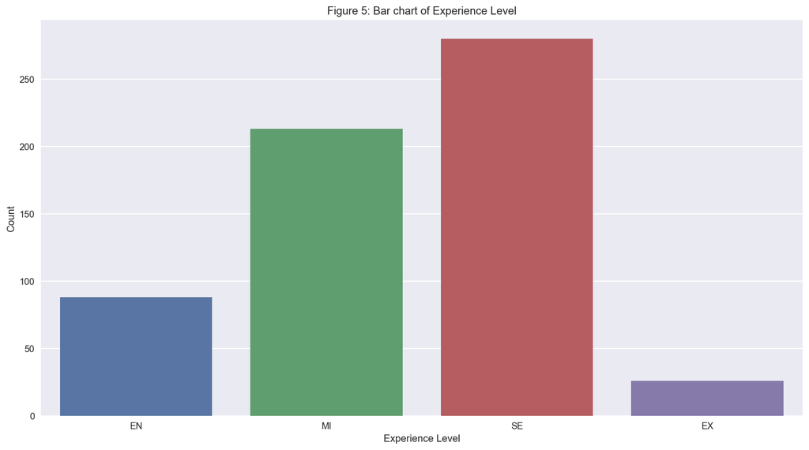

```python
plt.figure(figsize = (15,8))
ax = sns.countplot(ds_data['experience_level'], order=['EN', 'MI', 'SE', 'EX'])
plt.xlabel('Experience Level')
plt.ylabel('Count')
plt.title('Figure 5: Bar chart of Experience Level')
plt.show()
```

### Two-Variable Plots

#### Boxplot of Salary by Company Size

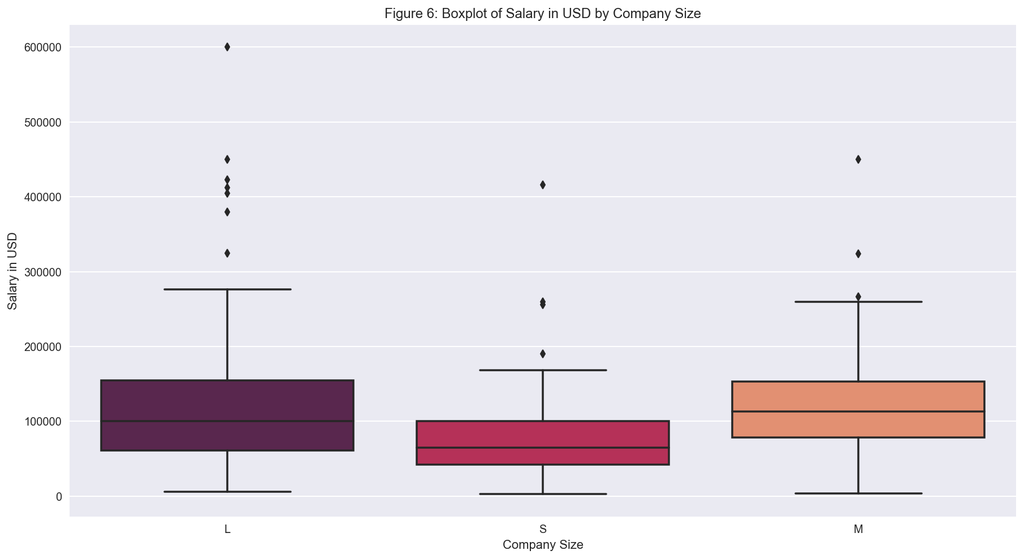

```python
plt.figure(figsize = (15,8))
sns.boxplot(ds_data['company_size'], ds_data['salary_in_usd'],  palette = 'rocket')
plt.title('Figure 6: Boxplot of Salary in USD by Company Size')
plt.xlabel('Company Size')
plt.ylabel('Salary in USD')
plt.show()
```

#### Boxplot of Salary by Year

It can be seen in Figure 7 that there is a consistent incline of salary over the past 3 years from 2020-2022. This may be due to the affects of Covid-19, and this specific industry requiring more employees, potentially being the reason for an increase in salary.

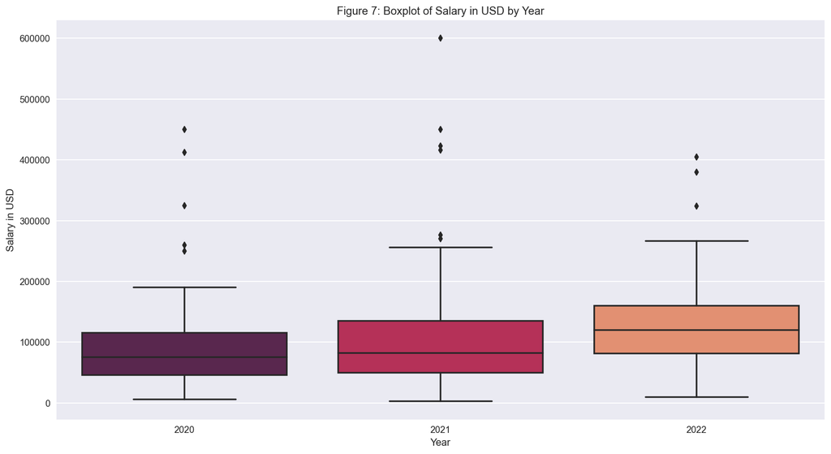

```python
plt.figure(figsize = (15,8))
sns.boxplot(ds_data['work_year'], ds_data['salary_in_usd'], palette = 'rocket')
plt.title('Figure 7: Boxplot of Salary in USD by Year')
plt.xlabel('Year')
plt.ylabel('Salary in USD')
plt.show()
```

#### Histogram of Salary by Employment Type

In Figure 8, you can see that salary does not seem to have much affect on the employment type of 'CT', 'PT', and 'FL'. However, it can be noted that most employees are fulltime, and can see that the darker area is where majority of employees salaries are sitting, but there are a few outliers in the higher salary range.

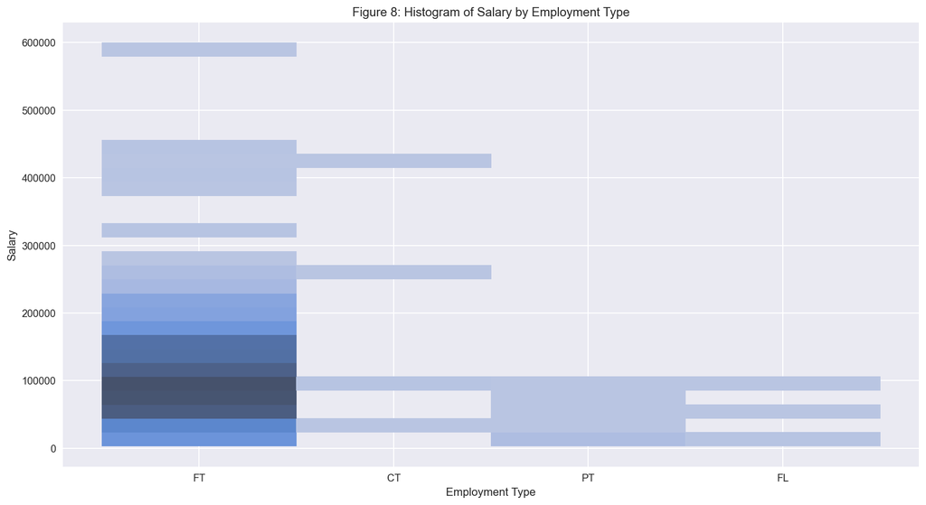

```python
plt.figure(figsize = (15,8))
sns.histplot(x= ds_data['employment_type'], y=ds_data['salary_in_usd'])
plt.title('Figure 8: Histogram of Salary by Employment Type')
plt.xlabel('Employment Type')
plt.ylabel('Salary')
```

#### Bar chart of Most Common Job Title by Employment Type

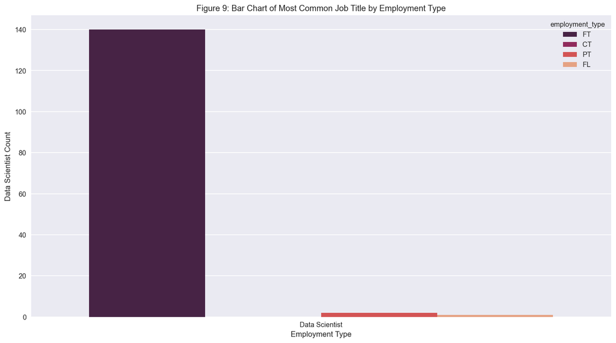

```python
plt.figure(figsize = (15,8))
sns.countplot(x = ds_data[ds_data['job_title'] == 'Data Scientist']['job_title'], hue = ds_data['employment_type'], palette = 'rocket')
plt.title('Figure 9: Bar Chart of Most Common Job Title by Employment Type')
plt.xlabel('Employment Type')
plt.ylabel('Data Scientist Count')
```

#### Bar Chart of US Company Residence by Company Size

The counts of employees in the residence of the US against different companysizes can be seen in Figure 10. It's interesting to see that a high amount of employees in the US are working in medium sized companies, followed by a lesser amount in Large companies, and a scarce amount working in small companies.

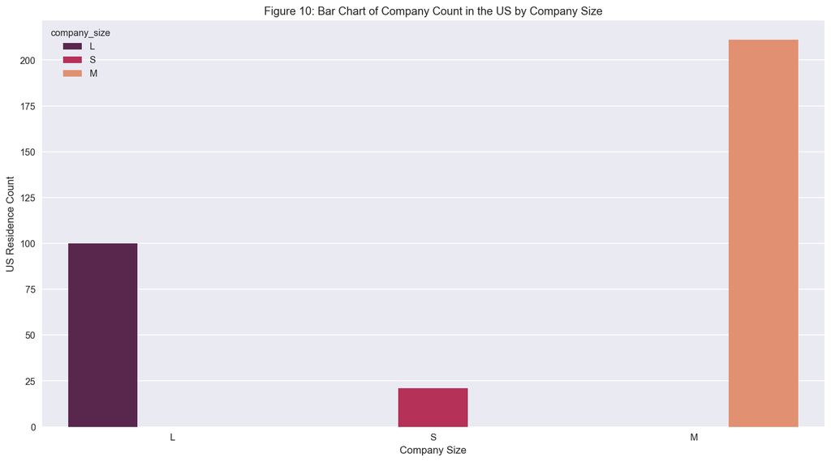

```python
plt.figure(figsize = (15,8))
sns.countplot(x = ds_data[ds_data['employee_residence'] == 'US']['company_size'], hue = ds_data['company_size'], palette = 'rocket')
plt.title('Figure 10: Bar Chart of Company Count in the US by Company Size')
plt.xlabel('Company Size')
plt.ylabel('US Residence Count')
```

### Three-Variable Plots

#### Boxplot of Salary by Employment Type and Experience Level

We observe in the boxplot below that as the experience level increases, so does the salary as a whole. Moreover, it can also be seen that Data Science Jobs are more common as a Full Time employment type compared to the other ones; Part Time which comes next, then Contract (which is more common for Entry Level Data Scientists) and Freelance (which is more common for Mid-Level Data Scientists), in that same order.

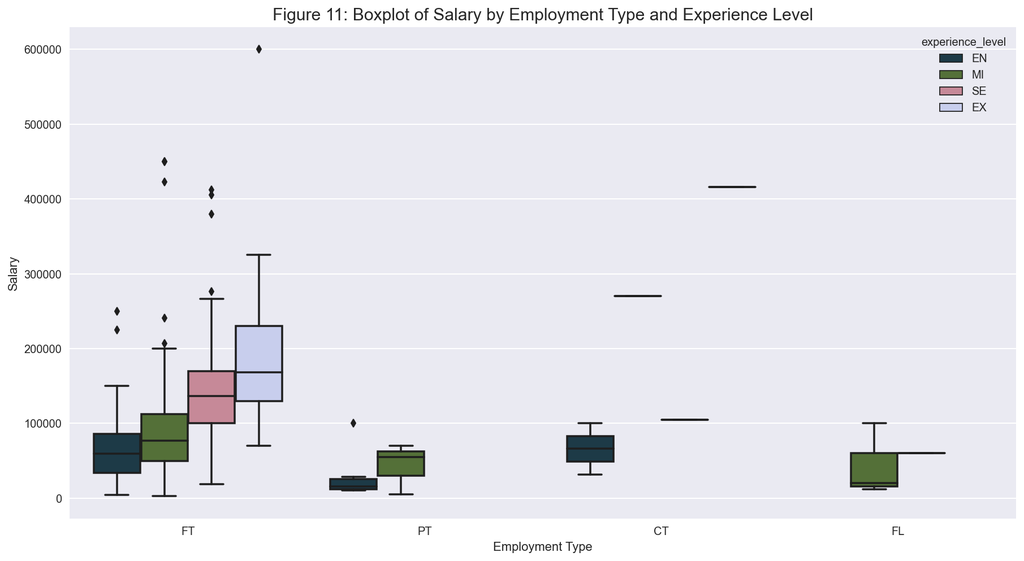

```python
plt.figure(figsize = (15,8))
sns.boxplot(ds_data['employment_type'], ds_data['salary_in_usd'], hue = ds_data['experience_level'], order=['FT', 'PT', 'CT', 'FL'], hue_order = ['EN', 'MI', 'SE', 'EX'], palette = 'cubehelix')
plt.xlabel('Employment Type')
plt.ylabel('Salary')
plt.title('Figure 11: Boxplot of Salary by Employment Type and Experience Level', fontsize = 15)
plt.show()
```

#### Boxplot of Salary by Year and Remote Ratio

An increase in salary is clearly evident in Figure 12 from 2020 to 2022 for non-remote and fully-remote employees. However, for partially remote data scientists, there seems to only be a slight increase throughout the years as seen by the mean.

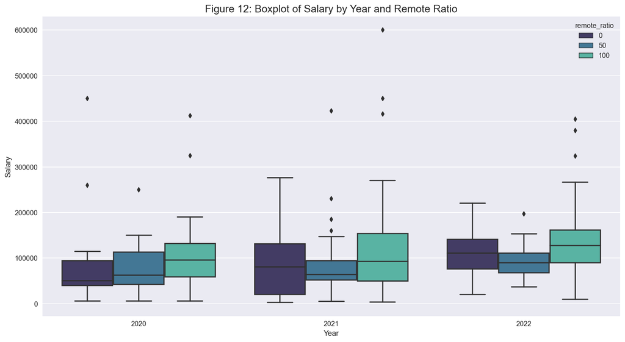

```python
plt.figure(figsize = (15,8))
sns.boxplot(ds_data['work_year'], ds_data['salary_in_usd'], hue = ds_data['remote_ratio'], palette = 'mako')
plt.xlabel('Year')
plt.ylabel('Salary')
plt.title('Figure 12: Boxplot of Salary by Year and Remote Ratio', fontsize = 15)
plt.show()
```

#### Lineplot of Salary by Remote Ratio and Experience Level

We observe an increase in salary as remote ratio increases. Moreover, this observation is also clearer as the experience level is higher. Although an increase is observed overall, Mid-level, Senior-level, and Executive-level of experience actually has a decline from non-remote to partially-remote employees. The increase happens drastically from partially-remote to fully-remote categories where the salary is also above the non-remote category.

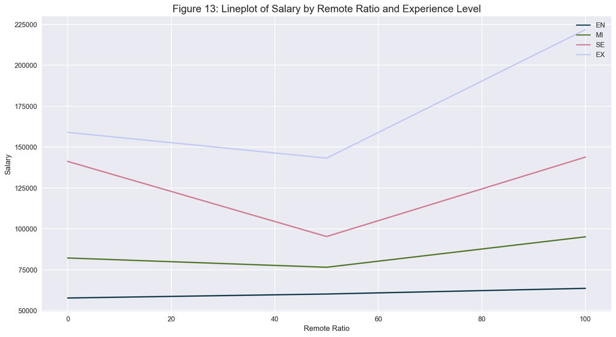

```python
plt.figure(figsize = (15,8))
sns.lineplot(ds_data['remote_ratio'], ds_data['salary_in_usd'], hue = ds_data['experience_level'], hue_order = ['EN', 'MI', 'SE', 'EX'], ci = None, palette = 'cubehelix', linewidth = 2)
plt.title('Figure 13: Lineplot of Salary by Remote Ratio and Experience Level', fontsize = 15);
plt.ylabel('Salary')
plt.xlabel('Remote Ratio')
plt.legend(loc = 'upper right')
plt.show();
```

#### Bar Chart of Fully Remote Employees Per Work Year and Company Size

In Figure 14, there are no similary patterns between the different company sizes.

As for the count, small companies had more fully remote employees in 2021 compared to 2020. However, this then dropped in 2022 even below the count of 2020. As an overall percentage of all employees in that year, the percentage of fully remote employees decreased from 2020 to 2022.

For medium-sized companies, the number and percentage of fully remote employees increased throughout the years, with a drastic increase between 2021 and 2022.

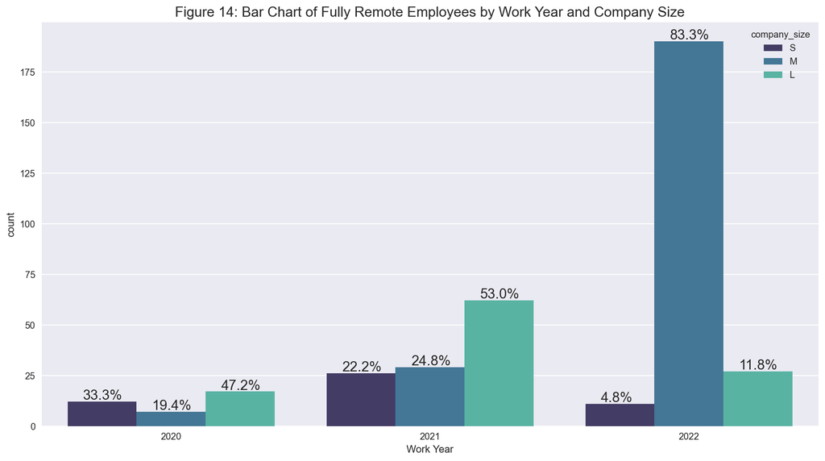

```python
# prepare required data
totalCount = []

for year in range(2020, 2023):
  totalCount.append(ds_data[(ds_data['remote_ratio'] == 100) & (ds_data['work_year'] == year)].shape[0])

plt.figure(figsize=(15,8))
ax = sns.countplot(x=ds_data[ds_data['remote_ratio'] == 100]['work_year'], hue = ds_data['company_size'], hue_order = ['S', 'M', 'L'], palette = 'mako')
plt.title('Figure 14: Bar Chart of Fully Remote Employees by Work Year and Company Size', fontsize=15)
plt.xlabel('Work Year')

count = 1
for p in ax.patches:
    if count in (1,4,7):
      total = totalCount[0]

    elif count in (2,5,8):
      total = totalCount[1]

    else:
      total = totalCount[2]

    percentage = '{:.1f}%'.format(100 * p.get_height()/total)
    x = p.get_x() + 0.06
    y = p.get_height() + 1
    ax.annotate(percentage, (x, y), fontsize = 15)

    count += 1

plt.show()
```

#### Barplot of Salary by Company Size and Experience Level

Overall, an increase in salary can be seen as the company size and experience level increases. However, for Entry-level and Executive-level of experience, the salary is lower in medium companies compared to small companies, but this increases above small company salaries in large companies. Moreover, the confidence interval line is longer for Executive-level, which may be because there are fewer Executive-level data scientists.

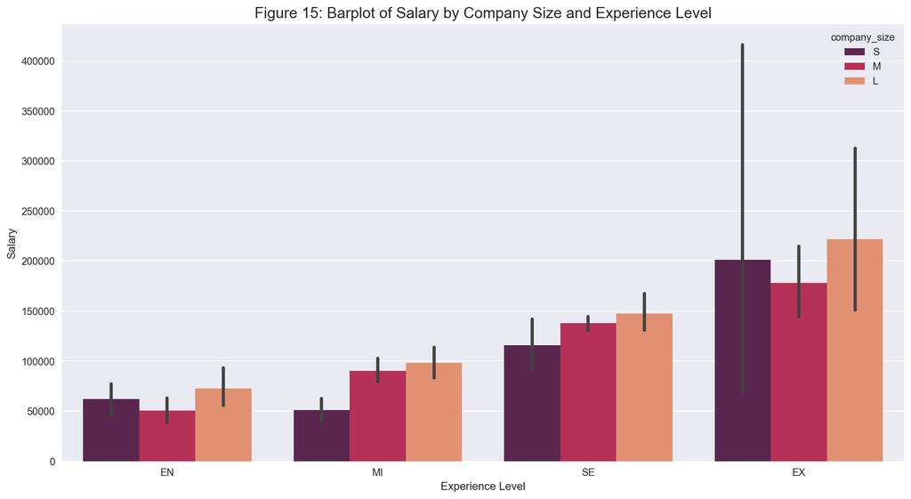

```python
plt.figure(figsize = (15,8))
sns.barplot(x ='experience_level', y ='salary_in_usd', hue = 'company_size', data = ds_data, order = ['EN', 'MI', 'SE', 'EX'], hue_order = ['S', 'M', 'L'], palette = 'rocket')
plt.title('Figure 15: Barplot of Salary by Company Size and Experience Level', fontsize = 15)
plt.xlabel('Experience Level')
plt.ylabel('Salary')
plt.show()
```

## Summary & Conclusion

Data science and adjacent fields are a rapidly growing and complex industry, with the salaries to prove that it is a vital and sought-after practice looking towards the future. Our goal with the project is to analyse the trends in the salaries, compared to experience level and fields of particular data science genres. This will then help us determine a reliable way to predict salaries using specific features.

Firstly, we started Phase 1 with data cleaning and preprocessing by dropping the columnms that would not be necessary in this project which are the 'salary' and 'salary_currency'. The dataset was then checked for missing or unusual values, which returned no concerns. Overall, the dataset was already clean so there was not much changes necessary aside from dropping columns. The data and data types were as inteded and sampling was not needed as there are only about 600 observations in the dataset.

We generated a variety of graphic solutions to explore the data. We found that senior-level employees are the most commonnly hired, and employees were most commonly full-time, whereas those considered executive-level were significantly less in quantity. We also found that the overall median wage for a data scientist was around $100k USD. The salary tend to increase as the work year, company size, and experience level increases and employees who are working full time also tend to have a higher salary compared to those who are not.

## References

- Bhatia, Ruchi. Data Science Job Salaries (Kaggle). Retrieved on the 27th of September 2022 from https://www.kaggle.com/datasets/ruchi798/data-science-job-salaries?resource=download%2F